# Predicting Soybean Classifications with a Random Forest

May 5, 2017

The soybean data can also be found at the UC Irvine Machine Learning Repository. Data were collected to predict disease in 683 soybeans. The 35 predictors are mostly categorical and include information on the environmental conditions (e.g., temperature, precipitation) and plant conditions (e.g., left spots, mold growth). The outcome labels consist of 19 distinct classes.

# Getting Started

```r
rm(list = ls())
library(caret)
library(ggplot2)
library(plotly)
library(AppliedPredictiveModeling)
library(magrittr)
library(mlbench)
library(impute)
library(Amelia)
library(corrplot)
library(randomForest)
library(caTools)
data("Soybean")
```

The task here will be to create a random forest model to classify the class of a given soybean based on it’s numerical characteristics. The classess we will be predicting are shown below. Here, I remove the `Class` variable from the data frame so that we can pre-process the data without manipulating the response variable.

```r
Class = Soybean$Class
Soybean$Class = NULL
unique(Class)
```

```
##  [1] diaporthe-stem-canker       charcoal-rot
##  [3] rhizoctonia-root-rot        phytophthora-rot
##  [5] brown-stem-rot              powdery-mildew
##  [7] downy-mildew                brown-spot
##  [9] bacterial-blight            bacterial-pustule
## [11] purple-seed-stain           anthracnose
## [13] phyllosticta-leaf-spot      alternarialeaf-spot
## [15] frog-eye-leaf-spot          diaporthe-pod-&-stem-blight
## [17] cyst-nematode               2-4-d-injury
## [19] herbicide-injury
## 19 Levels: 2-4-d-injury alternarialeaf-spot ... rhizoctonia-root-rot
```

```r
Soybean = Soybean[,-1]
```

# Dealing with Low Variance

Next, we analyze the variance of the predictor variables. Variance is useful in prediction. Take the opposite case, a zero-variance column. A zero-variance column will consist of only one data point. Say, the columns simply states “Soybean” all the way down. Well, this is obviously useless because it tells us nothing.

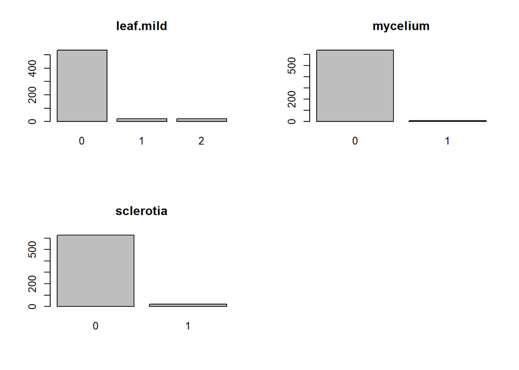

```r
zeroVarCols = nearZeroVar(Soybean)

par(mfrow = c(2,2)) # This allows us to plot charts side by side

for(i in zeroVarCols) {
  plot(Soybean[i], main = colnames(Soybean[i]))
}

par(mfrow = c(1,1)) # This sets the charting format back to normal
```

Let’s remove these because they will not be useful for us.

```r
Soybean = Soybean[,-zeroVarCols]
```

# Dealing with Missing Data

Next, we need to deal with the missing data. There is a pretty large amount of missing data within the `Soybeans` dataset. I love this function from the `Amelia` datset called `missmap`. Here, we can can see exactly what is missing and where.

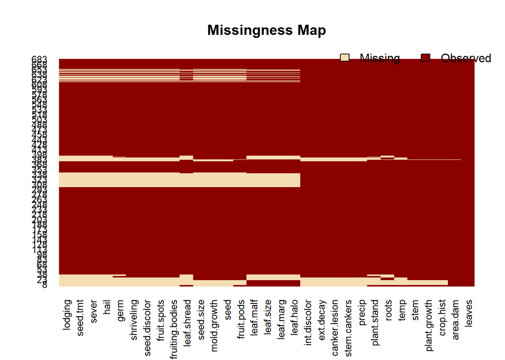

```r
missmap(Soybean)
```

# Creating Dummy Variables

Next, let’s create dummy variables and then convert the returned matrix back into a data frame. This will split up the factors into indicator variables.

```r
dv = dummyVars(formula = ~ ., Soybean)
sb = predict(dv, Soybean)
sb = as.data.frame(sb)
```

Let’s now look at the missing data.

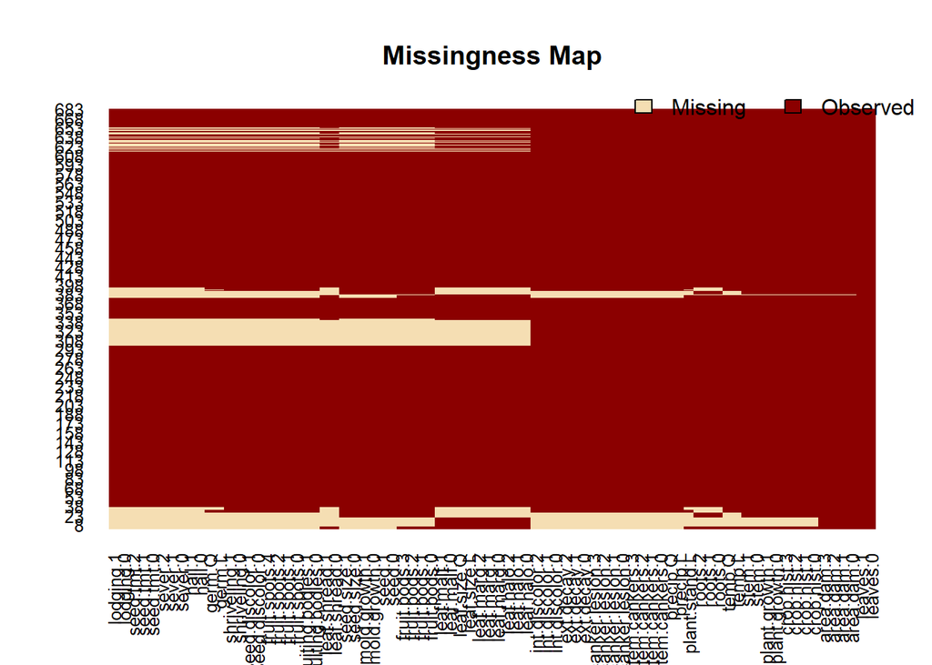

```r
missmap(sb)
```

So, now we have all this missing data, what are we to do with it? We can use a k-nearest neighbors approach and impute. Without going into too much detail, we basically look at the rest of the dataset and make an informed guess as to what the actual value should be. This will allow us to retain rows with missing data.

Now we have a full data frame.

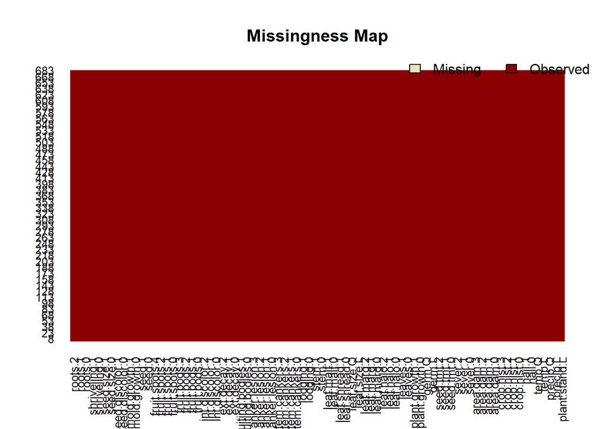

```r
sb = impute.knn(as.matrix(sb))
sb = as.data.frame(sb$data)
missmap(sb)
```

# Dealing with Multicollinearity

Next, let’s remove rows with high correlations. If we have high correlations, then we can run into issues like multicolinearity. If two columns are highly correlated, we aren’t getting much additional information.

```r
correlations = cor(sb)
highCorr = findCorrelation(correlations, cutoff = .75)
```

Let’s see what he correlation matrix looks like with the highly correlated columns. The “hclust” parameter orders the correlations to cluster like predictors together.

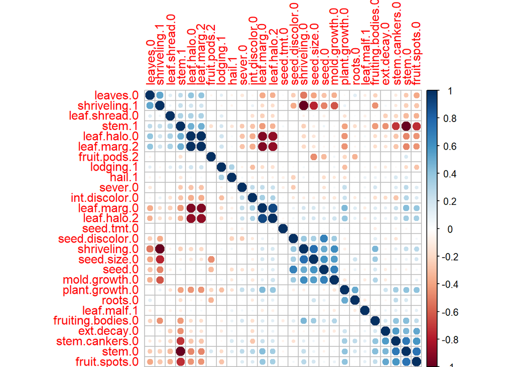

```r
corrplot(cor(sb[highCorr]), order = "hclust")
```

What about uncorrelated columns? We’re going to keep these for the analysis. Here we see that the clusters are generally speaking low correlations.

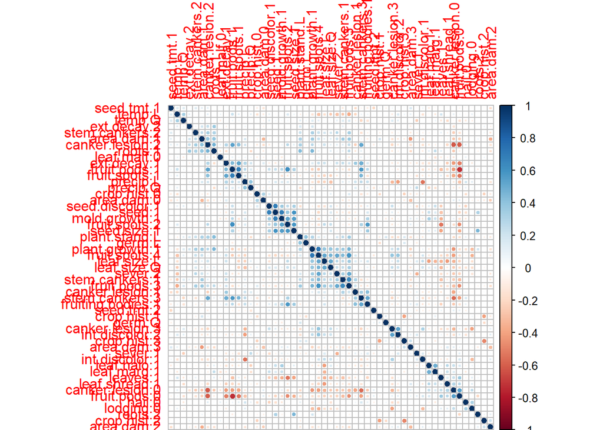

```r
corrplot(cor(sb[-highCorr]), order = "hclust")
```

Let’s remove the highly correlated columns now.

```r
sb = sb[-highCorr]
```

# Prepping For the Model

Now, we’re prep for the training model. First, we need to put the `Class` response variable back in the data.

```r
sb$Class = Class
head(sb$Class)
```

```
## [1] diaporthe-stem-canker diaporthe-stem-canker diaporthe-stem-canker
## [4] diaporthe-stem-canker diaporthe-stem-canker diaporthe-stem-canker
## 19 Levels: 2-4-d-injury alternarialeaf-spot ... rhizoctonia-root-rot
```

Now, we’ll use the `sample.split` function to split the the data into `train` and `test` data frames.

```r
# splitSamp = sample.split(sb, SplitRatio = .8)
SplitRatio = .8
splitSamp= sample.split(sb, SplitRatio = SplitRatio)

train = sb[splitSamp,]
test = sb[-splitSamp,]
```

# Running the Random Forest

Here, we will use the `randomForest` to create a random forest model and call it `rf.model` using the `train` dataset.

```r
rf.model = randomForest(Class ~ ., train)
```

Next, we use the `test` dataset to predict the soybean classes.

```r
rf.pred = predict(rf.model, test)

rf.model
```

```
##
## Call:
##  randomForest(formula = Class ~ ., data = train)
##                Type of random forest: classification
##                      Number of trees: 500
## No. of variables tried at each split: 7
##
##         OOB estimate of  error rate: 8.81%
## Confusion matrix:
##                             2-4-d-injury alternarialeaf-spot anthracnose
## 2-4-d-injury                          13                   0           0
## alternarialeaf-spot                    0                  67           0
## anthracnose                            0                   0          34
## bacterial-blight                       0                   0           0
## bacterial-pustule                      0                   0           0
## brown-spot                             0                   8           0
## brown-stem-rot                         0                   0           0
## charcoal-rot                           0                   0           0
## cyst-nematode                          0                   0           0
## diaporthe-pod-&-stem-blight            0                   0           0
## diaporthe-stem-canker                  0                   0           0
## downy-mildew                           0                   0           0
## frog-eye-leaf-spot                     0                  18           0
## herbicide-injury                       0                   0           0
## phyllosticta-leaf-spot                 0                   3           0
## phytophthora-rot                       0                   0           0
## powdery-mildew                         0                   0           0
## purple-seed-stain                      0                   0           0
## rhizoctonia-root-rot                   0                   0           0
##                             bacterial-blight bacterial-pustule brown-spot
## 2-4-d-injury                               0                 0          0
## alternarialeaf-spot                        0                 0          3
## anthracnose                                0                 0          0
## bacterial-blight                          16                 0          0
## bacterial-pustule                          1                17          0
## brown-spot                                 0                 0         60
## brown-stem-rot                             0                 0          0
## charcoal-rot                               0                 0          0
## cyst-nematode                              0                 0          0
## diaporthe-pod-&-stem-blight                0                 0          0
```

[output cut: 134 more lines]

```
## bacterial-pustule                              0  0.05555556
## brown-spot                                     0  0.17808219
## brown-stem-rot                                 0  0.00000000
## charcoal-rot                                   0  0.00000000
## cyst-nematode                                  0  0.00000000
## diaporthe-pod-&-stem-blight                    0  0.00000000
## diaporthe-stem-canker                          0  0.00000000
## downy-mildew                                   0  0.00000000
## frog-eye-leaf-spot                             0  0.29166667
## herbicide-injury                               0  0.00000000
## phyllosticta-leaf-spot                         0  0.37500000
## phytophthora-rot                               0  0.00000000
## powdery-mildew                                 0  0.00000000
## purple-seed-stain                              0  0.00000000
## rhizoctonia-root-rot                          17  0.00000000
```

```r
# plot(rf.model)
```

Next, we’ll make a confustion matrix and look at our accuracy!

```r
table(rf.pred, test$Class)
```

```
##
## rf.pred                       2-4-d-injury alternarialeaf-spot anthracnose
##   2-4-d-injury                          16                   0           0
##   alternarialeaf-spot                    0                  89           0
##   anthracnose                            0                   0          44
##   bacterial-blight                       0                   0           0
##   bacterial-pustule                      0                   0           0
##   brown-spot                             0                   0           0
##   brown-stem-rot                         0                   0           0
##   charcoal-rot                           0                   0           0
##   cyst-nematode                          0                   0           0
##   diaporthe-pod-&-stem-blight            0                   0           0
##   diaporthe-stem-canker                  0                   0           0
##   downy-mildew                           0                   0           0
##   frog-eye-leaf-spot                     0                   2           0
##   herbicide-injury                       0                   0           0
##   phyllosticta-leaf-spot                 0                   0           0
##   phytophthora-rot                       0                   0           0
##   powdery-mildew                         0                   0           0
##   purple-seed-stain                      0                   0           0
##   rhizoctonia-root-rot                   0                   0           0
##
## rf.pred                       bacterial-blight bacterial-pustule
##   2-4-d-injury                               0                 0
##   alternarialeaf-spot                        0                 0
##   anthracnose                                0                 0
##   bacterial-blight                          20                 0
##   bacterial-pustule                          0                20
##   brown-spot                                 0                 0
##   brown-stem-rot                             0                 0
##   charcoal-rot                               0                 0
##   cyst-nematode                              0                 0
##   diaporthe-pod-&-stem-blight                0                 0
##   diaporthe-stem-canker                      0                 0
##   downy-mildew                               0                 0
##   frog-eye-leaf-spot                         0                 0
##   herbicide-injury                           0                 0
##   phyllosticta-leaf-spot                     0                 0
##   phytophthora-rot                           0                 0
##   powdery-mildew                             0                 0
```

[output cut: 134 more lines]

```
##   bacterial-pustule                              0
##   brown-spot                                     0
##   brown-stem-rot                                 0
##   charcoal-rot                                   0
##   cyst-nematode                                  0
##   diaporthe-pod-&-stem-blight                    0
##   diaporthe-stem-canker                          0
##   downy-mildew                                   0
##   frog-eye-leaf-spot                             0
##   herbicide-injury                               0
##   phyllosticta-leaf-spot                         0
##   phytophthora-rot                               0
##   powdery-mildew                                 0
##   purple-seed-stain                              0
##   rhizoctonia-root-rot                          20
```

Our classifications were 98% accuracte. Pretty nice!

```r
acc1=paste0("Accuracy = ", round(sum(rf.pred == test$Class)/length(rf.pred), 5)*100, "%")
acc1
```

```
## [1] "Accuracy = 97.507%"
```

# Random Forest with No Pre-Processing

Ok, but what would happen if we didn’t do any of the pre-processing? That is, we were lazy. We’ll need to remove the NA rows and then create dummy variables like before.

```r
data("Soybean")
sb = Soybean
sb = sb[complete.cases(sb),]
Class = sb$Class
sb$Class = NULL

sb$date = NULL

dv = dummyVars(formula = ~ ., sb)
sb = predict(dv, sb)
sb = as.data.frame(sb)
sb$Class = Class
splitSamp= sample.split(sb, SplitRatio = SplitRatio)
sb=droplevels(sb)

train = sb[splitSamp,]
test = sb[-splitSamp,]


rf.model = randomForest(Class ~ ., train)
```

```r
rf.pred = predict(rf.model, test)

acc2 = paste0("Accuracy = ", round(sum(rf.pred == test$Class)/length(rf.pred), 5)*100, "%")
```

```r
paste("Good Model", acc1)
```

```
## [1] "Good Model Accuracy = 97.507%"
```

```r
paste("Bad Model", acc2)
```

```
## [1] "Bad Model Accuracy = 96.791%"
```